# Drzewa decyzyjne - algorytm ID3

Drzewo decyzyjne to struktura danych zorganizowanych w pewien graf reprezentujący decyzje i ich konsekwencje, w którym z każdego węzła (oprócz liści) wychodzą gałęzie reprezentujące poszczególne wartości atrybutu danych pełniącego funkcję klasyfikatora.

Podstawowym algorytmem budowania drzewa decyzyjnego jest algorytm ID3, bazujący na entropii informacyjnej i wartości zysku informacyjnego poszczególnych atrybutów.

## Elementy teorii informacji

Przedmiotem teorii informacji jest kwantyfikowanie informacji, czyli ujmowanie jej w sposób ilościowy, a także detale związane z jej przechowywaniem i przesyłaniem. Poniżej wyjaśnimy podstawowe dwa pojęcia, na których opiera się konstruowanie drzew decyzyjnych za pomocą algorytmu ID3.

### Entropia

W celu zbudowania drzewa decyzyjnego, będziemy musieli określić kryteria dokonywanego podziału, a także ustawić je w odpowieniej kolejności. Na każdym etapie drzewa będą znajdowały się jakieś możliwości, które wyelminowaliśmy, i inne, które czekają na podział. Każde pytanie dzieli pozostałe możliwości zgodnie z odpowiedzią.

Najlepiej byłoby, gdybyśmy zadawali pytania, które dają odpowiedzi zawierające dużo informacji na temat tego, co nasze drzewo powinno przewidzieć. "Ilość wnoszonych informacji" można określić właśnie za pomocą entropii, czyli swoistej miary niepewności związanej z danymi (nieuporządkowania czy też chaotyczności danych).

Ogólnie rzecz biorąc - gdyby wszystkie elementy danego zbioru należały do jednej klasy, to nie ma żadnego nieuporządkowania oraz żadnej niepewności decyzyjnej, a więc entropia byłaby niska (w granicy zerowa). W przypadku równego rozdziału elementów pomiędzy klasy mamy dużą niepewność, a więc wysoką entropię.

Jeżeli p określa część danych oznaczoną etykietami wskazującymi na przynależność do danej klasy, to entropię możemy opisać następującym równaniem:

[figure not shown]

Wprowadzając instrukcje warunkowe w naszej implementecji tego algorytmu zabezpieczamy się przed przypadkiem granicznym, czyli 0 * log 0 - poprzez ograniczenie rozważań do podzbiorów, zawierających daną kategorię.

Każdy czynnik $ -p_{i} log_{2} p_{i} $ jest wartością nieujemną i bliską zeru dokładnie wtedy, gdy wartość $ -p_{i} $ jest zbliżona do 0 lub 1, co obrazuje poniższy wykres.

[figure not shown]

Wynika z tego, że entropia będzie miała niską wartość, gdy każda wartość $p_{i}$ jest zbliżona do 0 lub 1 (tj. wtedy, gdy więkoszość danych należy do jednej klasy). Wartość entropii rośnie wtedy, gdy wiele czynników $p_{i}$ nie jest zbliżonych do zera (tj. wtedy, gdy dane należą do wielu klas).

### Entropia podziału

Obliczyliśmy entropię (miarę "niepewności") pojedyńczego zbioru danych oznaczonych etykietami. Teraz możemy rozpocząć pracę nad pytaniami tworzącymi kolejne etapy drzewa decyzyjnego, które pozwolą podzielić dane na części składające się - w naszym przypadku - z dwóch podzbiorów.

Potrzebujemy zatem entropii wynikającej z podziału zbioru danych w określony sposób. By dokładniej przybliżyć tę ideę, przejdziemy teraz do pojęcia zysku informacyjnego.

### Zysk informacyjny

Zysk informacyjny (ang. information gain) to analiza polegająca na wyszukiwaniu atrybutu warunkującego o największym zysku informacyjnym.

Zatem - obliczymy zysk informacyjny, aby wybrać cechę, która go maksymalizuje, a następnie dokonujemy podziału na podstawie tej cechy. Information gain jest pojęciem opartym na entropii i definiuje się go jako całkowitą entropię pomniejszoną o entropię, związaną z podziałem na podstawie danej cechy.

[figure not shown]

- H(S) – entropia całego zbioru
- T – podzbiory, które zostały utworzone z podziału zbioru S ze względu na atrybut A :

[figure not shown]

- p(t) - prawdopodobieństwo przynależności do zbioru t
- H(t) - entropia podzbioru t

Opis wzoru: information gain IG (A) jest miarą różnicy w entropii od przed do po rozdzieleniu zbioru S ze względu na atrybut A. Innymi słowy, o ile niepewność w S została zmniejszona po podzieleniu zbioru S ze względu na atrybut A.

## Dataset oraz opis problemu

Nasz zbiór danych jest iloczynem kartezjańskim wartości następujących przesłanek:

- **Pogoda**: gorąco, letnio, zimno, mrozno
- **Dyscyplina**: bouldering, lina, czasowki
- **Staż**: <3, 3-10, >10
- **Płeć**: kobieta, mezczyzna
- **Stan**: zmeczony, wypoczęty, srednie
- **Miejsce**: skaly, dom, scianka

Stworzony przez nas dataset zawiera przesłanki, które potencjalnie mogłyby wpłynąć na decyzję wspinacza odnośnie wyboru rodzaju aktywności wspinaczkowej (skały, ścianka) - lub jej braku (dom). Ostatnia kolumna jest zatem zmienną Y zawierającą etykiety dla poszczególnych obserwacji. Poszczególne przesłanki staraliśmy się dobrać w taki sposób, aby miały swoje odwzorowanie w rzeczywistych realiach świata wspinaczkowego - np. mroźna pogoda może sprzyjać boulderingowi w skałach itd. W projekcie spróbujemy zatem wyznaczyć granice decyzjne dla wskazanych danych oraz zaprezentować graficzne rozwiązanie problemu.

[figure not shown]

Tworząc dataset zwróciliśmy także uwagę, by unikać korzystania z atrybutów z dużą liczbą wartości, ponieważ mogłoby to doprowadzić do bardzo niskiej entropii z powodu nadmiernego dopasowania. Na przykład - zbiór danych zawierających numery PESEL doprowadziłby najprawdopodobniej do wygenerowania jednoosobowych podzbiorów, z których każdy charakteryzowałby się zerową entropią. Model opierający się na numerach PESEL nie generowałby uogólnień wykraczających poza treningowy zbiór danych. Co prawda w przypadku tego konkretnego datasetu cały zbiór danych jest zbiorem treningowym, jednak mieliśmy na uwadze, by unikać nadmiarowości w liczbie wartości atrybutów.

## Algorytm w praktyce

Poniżej przedstawimy zarys, co do działania impementacji algorytmu w praktyce. Dołożyliśmy starań, aby nasz kod był stosunkowo dokładnie opisany, zatem zachęcamy również do zapoznania się z komentarzami w source code.

Zaczyniemy od zestawu danych, w którym każdy wiersz odpowiada pojedynczej obserwacji. Kolumny datasetu to atrybuty, gdzie skrajna prawa kolumna to etykieta klasy.

Każdy atrybut może przyjąć zestaw wartości. Podczas uczenia drzewa decyzyjnego dzielimy obserwacje w zbiorze danych na podzbiory na podstawie wartości atrybutów. Na przykład atrybut *dyscyplina* można wykorzystać do utworzenia podzbioru wystąpień „boulderingu”, „liny” i „czasówek”. Następnie dzielimy każdy z tych podzbiorów jeszcze bardziej na podstawie innego atrybutu (np. stażu).

Budowanie drzewa decyzyjnego polega na wykorzystaniu wartości atrybutów do dalszego dzielenia danych na coraz mniejsze podzbiory **(rekurencyjnie)**, aż każdy podzbiór będzie satysfakcjonujący wobec hipermarametrów - czyli wobec zadanego poziomu information gain (nasz defaultowy model przyjmuje, że rozwijamy drzewo tak długo jak niesie to zysk informacyjny).

## Klasyfikowanie danych za pomocą drzew decyzyjnych

Gdy już zbudujemy drzewo decyzyjne dla zbioru danych, na podstawie atrybutów $A_{1}$, ..., $A_{n}$, jego elementów i klas decyzyjnych (labele), możemy to drzewo wykorzystać do klasyfikowania nowych elementów danych, opierając się na wartościach ich atrybutów.

Do badanego elementu, znając wartość atrybutu $A_{i}$ pełniącego rolę klasyfikatora w korzeniu drzewa decyzyjnego, wyruszamy z korzenia wzdłuż gałęzi odpowiadającej tej wartości. W węźle, do którego dotarliśmy, powtarzamy tę czynność (oczywiście biorąc pod uwagę atrybut związany z tym węzłem) - i tak dalej, dla kolejnych węzłów, aż dojdziemy do liścia. Ów liść reprezentować będzie atrybut decyzyjny, czyli jedną z klas, do której ostatecznie zaliczony zostanie badany element.

Choć wiemy, że etap ten nie był uwzględniony w wytycznych zadania, nie mogliśmy się powstrzymać przed implementacją i wypróbowaniem predykcji na dodatkowym zbiorze danych - z własnej ciekawości. Efekty klasyfikacji zostaną przedstawione w dalszej części.

## Pruning

Mówiąc o predykcji, nie sposób nie wspomnieć o pruningu - choć również jest to element wprowadzony przez nas dodatkowo - w ramach ćwiczenia i (ponownego) zaspokojenia własnej ciekawości.

Pruning (czy inaczej przycinanie) to technika kompresji danych w uczeniu maszynowym i algorytmach wyszukiwania, która zmniejsza rozmiar drzew decyzyjnych, usuwając sekcje drzewa, które są niekrytyczne i nadmiarowe w celu klasyfikowania wystąpień. Przycinanie zmniejsza złożoność ostatecznego klasyfikatora, a tym samym poprawia dokładność przewidywania poprzez zmniejszenie nadmiernego dopasowania.

Jednym z zagadnień, które pojawia się w algorytmie drzewa decyzyjnego, jest optymalna wielkość ostatecznego drzewa. Drzewo, które jest zbyt duże, grozi nadmiernym dopasowaniem danych szkoleniowych i słabym uogólnieniem na nowe próbki. Małe drzewo może nie przechwytywać ważnych informacji strukturalnych dotyczących przestrzeni próbki. Jednak trudno jest określić, kiedy algorytm drzewa powinien się zatrzymać, ponieważ nie można stwierdzić, czy dodanie jednego dodatkowego węzła dramatycznie zmniejszy błąd. Typową strategią jest powiększanie drzewa do momentu, gdy każdy węzeł zawiera niewielką liczbę instancji, a następnie użycie funkcji przycinania w celu usunięcia węzłów, które nie dostarczają dodatkowych informacji. Przycinanie powinno zmniejszyć rozmiar drzewa uczenia się bez zmniejszania dokładności predykcyjnej (mierzonej przez zestaw do walidacji krzyżowej - która jednak nie została przez nas już zaimplementowana). Istnieje wiele technik przycinania drzew, które różnią się miarą używaną do optymalizacji wydajności. W naszym przypadku posłużyliśmy się post-pruningiem od góry do dołu.

**Post-pruning** jest najczęstszym sposobem upraszczania drzew. Węzły i poddrzewa są zastępowane liśćmi, aby poprawić złożoność. Przycinanie, jak już wspomnieliśmy, może nie tylko znacznie zmniejszyć rozmiar, ale także poprawić dokładność klasyfikacji niewidocznych obiektów.

Teoretycznie może się zdarzyć, że dokładność przypisania na zbiorze testowym pogorszy się, ale dokładność właściwości klasyfikacyjnych drzewa ogólnie wzrośnie - choć jak wspomnieliśmy ten element nie został przez nas zweryfikowany na podstawie cross-validation. Procedury są zróżnicowane na podstawie ich podejścia w drzewie (od góry lub od dołu).

**Przycinanie od dołu do góry**

Te procedury rozpoczynają się w ostatnim węźle drzewa (najniższy punkt). Podążając rekurencyjnie w górę, określają znaczenie każdego pojedynczego węzła. Jeśli nie niesie to znaczenia dla klasyfikacji, węzeł jest usuwany lub zastępowany liściem.

## Podsumowanie

Budowanie drzewa rozpoczynamy od jego korzenia, reprezentującego dany zbiór jako całość. Z korzenia wyprowadzamy gałęzie odpowiadające podziałowi zbioru: każda z nich odpowiadająca jednej wartości atrybutu wybranego jako kryterium podziału, prowadzi do węzła reprezentującego jeden z podzbiorów stanowiących wynik tego podziału.

Regułę tę powtarzamy rekurencyjnie dla każdego z nowo utworzonych węzłów, ponownie dla każdego, wybierając atrybut warunkujący o największym zysku informacyjnym. Rekurencja kończy się, gdy w danym podzbiorze nie można już dokonać podziału, bo zachodzi conajmniej jedna z następujących okoliczności:

- wyczerpaliśmy wszystkie atrybuty warunkujące
- żaden atrybut warunkujący nie może być użyty jako kryterium podziału, ponieważ w podzbiorze występuje tylko jedna jego wartość
- żaden atrybut warunkujący nie może być użyty jako kryterium podziału, bo dla każdej jego wartości atrybut decyzyjny ma tę samą wartość

## Część praktyczna - przedstawienie wyników

Poniżej przedstawimy drzewo decyzyjne - a więc wyznaczone przez algorytm granice decyzyjne dla wszystkich obserwacji z naszego bazowego zbioru danych o wspinaczce. Poniższe wyniki zaprezentowane zostaną zarówno w postaci "printa" jak i wykresu - oby dwa bez zastosowania pruningu.

```python
import csv

import pandas as pd
from grow_decision_tree import grow_tree, plot, prune, predict


import matplotlib.pyplot as plt
import networkx as nx
from main import grow_and_show_tree
```

```
id=8736684489069,Column dyscyplina: x == czasowki?
yes -> id=8736684489089,Column pogoda: x == letnio?
		yes -> id=8736685655173,Column staz: x == <3?
				yes -> id=8736684489125,Column stan: x == zmeczony?
						yes -> id=8736684489129,Column plec: x == kobieta?
								yes -> {'skaly': 1}
								no  -> {'dom': 1}
						no  -> {'skaly': 4}
				no  -> id=8736684489173,Column stan: x == srednie?
						yes -> id=8736684474005,Column staz: x == 3-10?
								yes -> id=8736684473997,Column plec: x == kobieta?
										yes -> {'skaly': 1}
										no  -> {'dom': 1}
								no  -> {'dom': 2}
						no  -> {'skaly': 4, 'dom': 4}
		no  -> id=8736684489185,Column pogoda: x == zimno?
				yes -> id=8736684473929,Column stan: x == zmeczony?
						yes -> id=8736684474045,Column plec: x == kobieta?
								yes -> id=8736684474053,Column staz: x == <3?
										yes -> {'skaly': 1}
										no  -> id=8736684474041,Column staz: x == 3-10?
												yes -> {'scianka': 1}
												no  -> {'dom': 1}
								no  -> {'dom': 3}
						no  -> id=8736684474033,Column stan: x == wypoczęty?
								yes -> id=8736684474049,Column staz: x == 3-10?
										yes -> {'skaly': 2}
										no  -> {'dom': 2, 'skaly': 2}
								no  -> id=8736684474089,Column staz: x == 3-10?
										yes -> {'dom': 2}
										no  -> {'dom': 2, 'skaly': 2}
				no  -> id=8736684474029,Column staz: x == >10?
						yes -> id=8736684473985,Column stan: x == zmeczony?
								yes -> id=8736684474101,Column pogoda: x == goraco?
										yes -> id=8736684474057,Column plec: x == kobieta?
												yes -> {'scianka': 1}
												no  -> {'skaly': 1}
										no  -> {'skaly': 2}
								no  -> id=8736699096817,Column pogoda: x == mrozno?
										yes -> id=8736699096753,Column plec: x == kobieta?
```

[output cut: 431 more lines]

```
														no  -> {'dom': 2}
												no  -> id=8736684471685,Column stan: x == srednie?
														yes -> {'scianka': 2}
														no  -> {'scianka': 2, 'dom': 2}
										no  -> id=8736684471569,Column pogoda: x == zimno?
												yes -> id=8736684471705,Column stan: x == srednie?
														yes -> {'skaly': 1}
														no  -> {'dom': 2}
												no  -> id=8736684471729,Column pogoda: x == goraco?
														yes -> id=8736684471709,Column stan: x == zmeczony?
																yes -> {'skaly': 1}
																no  -> {'scianka': 2}
														no  -> id=8736684471717,Column stan: x == zmeczony?
																yes -> {'scianka': 1}
																no  -> {'skaly': 2}
```

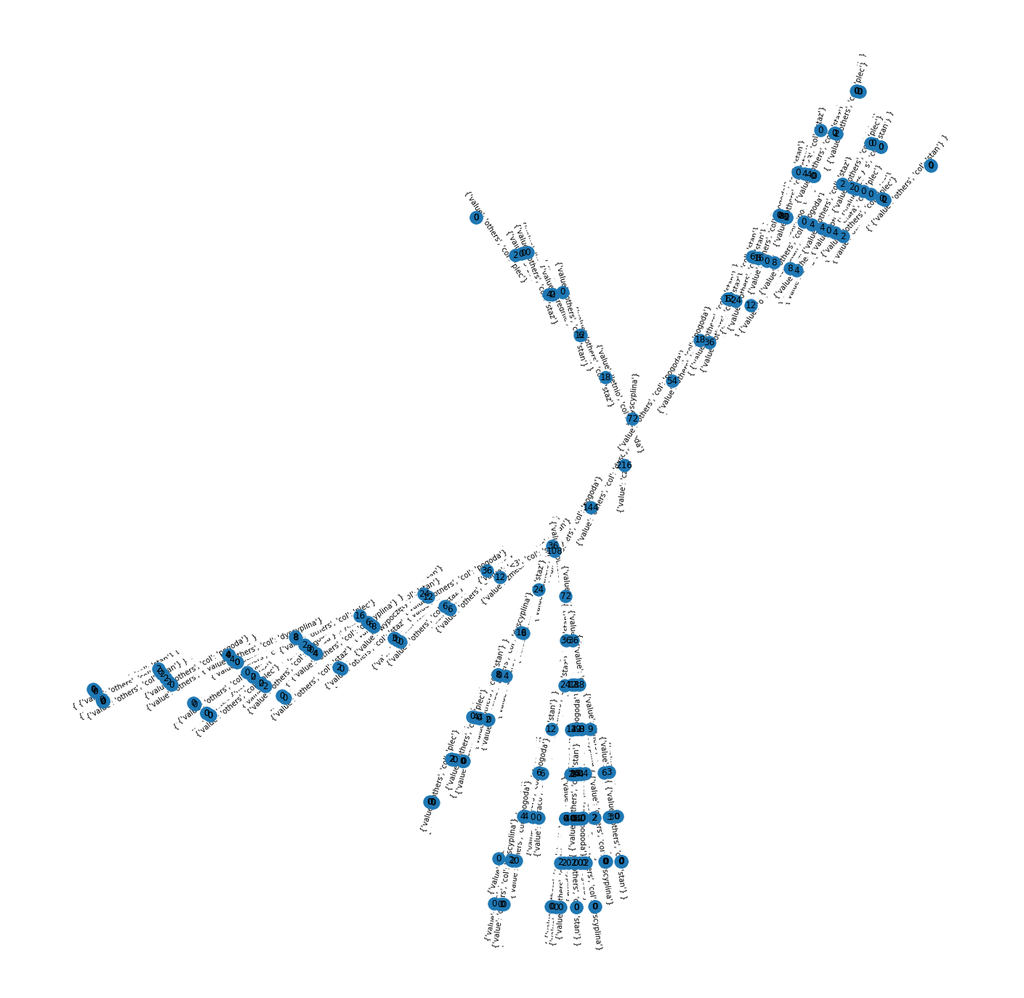

```python
filename1 = 'dane.csv'
d_tree1 = grow_and_show_tree(filename1, pruning=False)
```

Poniżej zaś przedstawimy jak prezentuje się drzewo po zastosowaniu pruningu (threshold, czyli minimalny zysk informacyjny wynosi 0.5). Jak będziemy mogli zauważyć obcięcie nastąpiło pięciokrotnie dla następujących wartości zysku informacyjnego:

- 0.251629
- 0.251629
- 0.081704
- 0.251629
- 0.251629

```
id=8736685164021,Column dyscyplina: x == czasowki?
yes -> id=8736673396773,Column pogoda: x == letnio?
		yes -> id=8736682504381,Column staz: x == <3?
				yes -> id=8736673401985,Column stan: x == zmeczony?
						yes -> id=8736673694981,Column plec: x == kobieta?
								yes -> {'skaly': 1}
								no  -> {'dom': 1}
						no  -> {'skaly': 4}
				no  -> id=8736673402009,Column stan: x == srednie?
						yes -> id=8736682251493,Column staz: x == 3-10?
								yes -> id=8736682251357,Column plec: x == kobieta?
										yes -> {'skaly': 1}
										no  -> {'dom': 1}
								no  -> {'dom': 2}
						no  -> {'skaly': 4, 'dom': 4}
		no  -> id=8736682251461,Column pogoda: x == zimno?
				yes -> id=8736673384653,Column stan: x == zmeczony?
						yes -> id=8736673384549,Column plec: x == kobieta?
								yes -> id=8736673384749,Column staz: x == <3?
										yes -> {'skaly': 1}
										no  -> id=8736673384737,Column staz: x == 3-10?
												yes -> {'scianka': 1}
												no  -> {'dom': 1}
								no  -> {'dom': 3}
						no  -> id=8736673384669,Column stan: x == wypoczęty?
								yes -> id=8736673384785,Column staz: x == 3-10?
										yes -> {'skaly': 2}
										no  -> {'dom': 2, 'skaly': 2}
								no  -> id=8736673384741,Column staz: x == 3-10?
										yes -> {'dom': 2}
										no  -> {'dom': 2, 'skaly': 2}
				no  -> id=8736673384725,Column staz: x == >10?
						yes -> id=8736673384733,Column stan: x == zmeczony?
								yes -> id=8736673384841,Column pogoda: x == goraco?
										yes -> id=8736673384829,Column plec: x == kobieta?
												yes -> {'scianka': 1}
												no  -> {'skaly': 1}
										no  -> {'skaly': 2}
								no  -> id=8736673384853,Column pogoda: x == mrozno?
										yes -> id=8736673384869,Column plec: x == kobieta?
```

[output cut: 426 more lines]

```
												yes -> id=8736684430541,Column stan: x == zmeczony?
														yes -> {'scianka': 1}
														no  -> {'dom': 2}
												no  -> {'a': 4, 'm': 2}
										no  -> id=8736684430533,Column pogoda: x == zimno?
												yes -> id=8736684430585,Column stan: x == srednie?
														yes -> {'skaly': 1}
														no  -> {'dom': 2}
												no  -> id=8736684430109,Column pogoda: x == goraco?
														yes -> id=8736684430089,Column stan: x == zmeczony?
																yes -> {'skaly': 1}
																no  -> {'scianka': 2}
														no  -> id=8736684430097,Column stan: x == zmeczony?
																yes -> {'scianka': 1}
																no  -> {'skaly': 2}
```

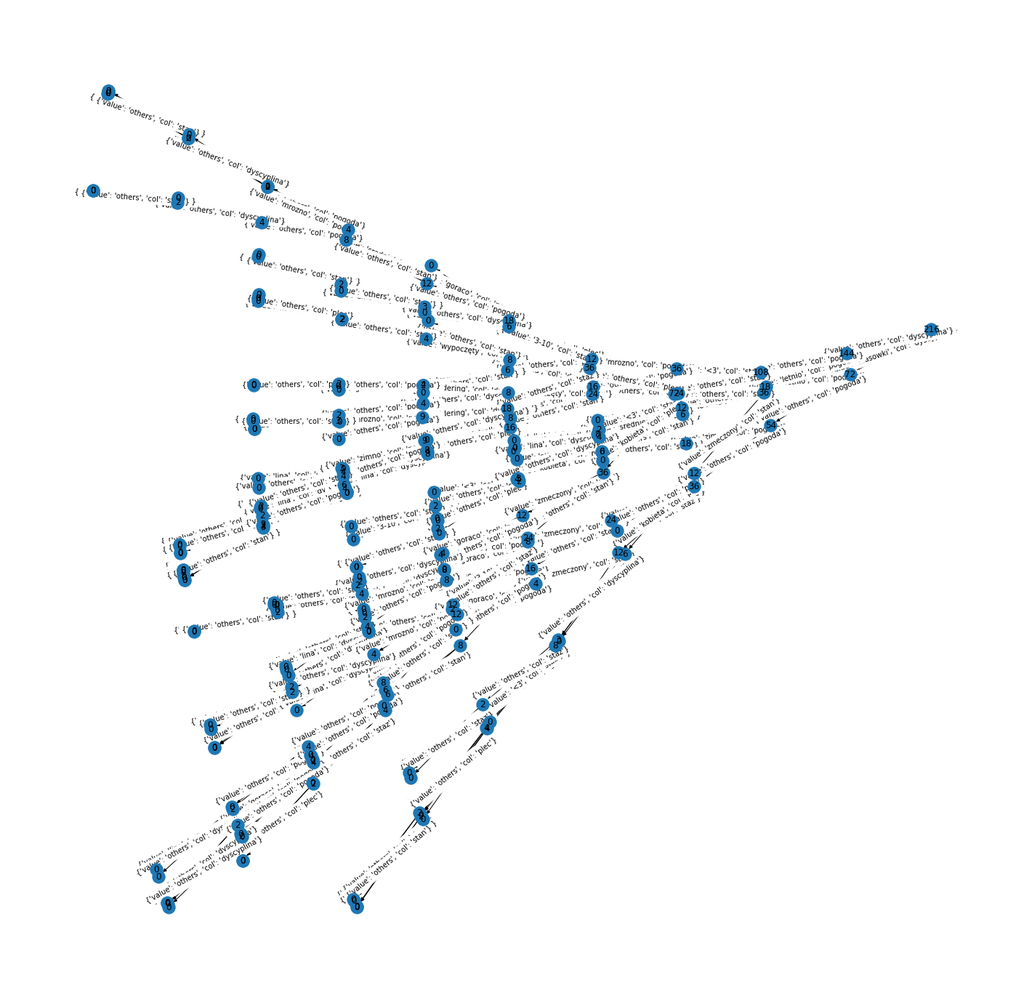

```python
d_tree2 = grow_and_show_tree(filename1, pruning=True, threshold=0.5)
```

Jak możemy zauważyć nasze drzewo jest dosyć mocno rozbudowane, co może wynikać z braku ewidentnej tendencji w potencjalnych wspinaczkowych decyzjach.

W ramach wprawki do dalszego zgłebiania wiedzy z zakresu machine learningu postanowiliśmy również stworzyć drzewa decyzyjne oraz predykcję dla dwóch dodatkowcyh zbiorów danych. Pierwszy z nich - indians_diabetes składa się z kilku medycznych zmiennych predykcyjnych i jednej zmiennej docelowej - wyniku. Zmienne predykcyjne obejmują liczbę ciąż, które pacjentka miała kobieta, BMI, poziom insuliny, wiek i tak dalej. Ten zbiór danych pochodzi z National Institute of Diabetes and Digestive and Kidney Diseases. Celem wykorzystania zbioru danych jest diagnostyczne przewidywanie, czy pacjent ma cukrzycę, na podstawie określonych pomiarów diagnostycznych zawartych w zestawie danych. Na wybór tych instancji z większej bazy danych nałożono kilka ograniczeń. W szczególności wszyscy pacjenci to kobiety w wieku co najmniej 21 lat pochodzenia indiańskiego Pima. Poniżej zaprezentujemy drzewo decyzyjne wraz z zastosowanym pruningiem, później zaś rezultaty klasyfikacji dla danych, wymyślonych przez nas wartości.

Zauważmy, że ze względu na dużą liczbę danych eksperymentalnie zastosowaliśmy wysoką wartość thresholdu pruningu.

```
id=8736682251485 Column 148: x >= 128.0?
yes -> id=8736673362557 Column 33.6: x >= 30.0?
		yes -> id=8736671645421 Column 148: x >= 158.0?
				yes -> id=8736673367965 Column 0: x >= 680.0?
						yes -> id=8736671390441 Column 72: x >= 70.0?
								yes -> {0.0: 2}
								no  -> {1.0: 1}
						no  -> id=8736671383457 Column 0.627: x >= 0.344?
								yes -> id=8736671383389 Column 50: x >= 45.0?
										yes -> id=8736671383549 Column 6: x >= 7.0?
												yes -> {1.0: 7}
												no  -> id=8736671383529 Column 6: x >= 6.0?
														yes -> {0.0: 2}
														no  -> id=8736671383429 Column 6: x >= 1.0?
																yes -> {1.0: 5}
																no  -> {0.0: 1}
										no  -> {1.0: 42}
								no  -> id=8736671383329 Column 33.6: x >= 35.5?
										yes -> id=8736671383537 Column 33.6: x >= 47.9?
												yes -> id=8736671383497 Column 6: x >= 8.0?
														yes -> {1.0: 1}
														no  -> {0.0: 1}
												no  -> {1.0: 13}
										no  -> id=8736671383369 Column 148: x >= 193.0?
												yes -> {1.0: 3}
												no  -> id=8736671383525 Column 148: x >= 179.0?
														yes -> id=8736671383413 Column 6: x >= 3.0?
																yes -> {0.0: 4}
																no  -> {1.0: 1}
														no  -> id=8736671383481 Column 0.627: x >= 0.295?
																yes -> id=8736671383385 Column 6: x >= 9.0?
																		yes -> {1.0: 1}
																		no  -> {0.0: 2}
																no  -> {1.0: 6}
				no  -> id=8736673384413 Column 72: x >= 62.0?
						yes -> id=8736673384305 Column 50: x >= 31.0?
								yes -> id=8736673384353 Column 0.627: x >= 0.439?
										yes -> id=8736673384337 Column 33.6: x >= 38.7?
												yes -> id=8736673384349 Column 72: x >= 84.0?
														yes -> {0.0: 3}
```

[output cut: 451 more lines]

```
														no  -> id=8736673357921 Column 72: x >= 58.0?
																yes -> id=8736673357929 Column 0.627: x >= 0.278?
																		yes -> {1.0: 1}
																		no  -> id=8736673357905 Column 148: x >= 95.0?
																				yes -> id=8736673357957 Column 148: x >= 101.0?
																						yes -> id=8736673357973 Column 33.6: x >= 34.1?
																								yes -> {0.0: 8}
																								no  -> id=8736673357897 Column 148: x >= 125.0?
																										yes -> {0.0: 1}
																										no  -> {1.0: 1}
																						no  -> {1.0: 1}
																				no  -> {0.0: 9}
																no  -> {1.0: 2}
						no  -> {1.0: 2}
				no  -> {1.0: 2, 0.0: 149}
```

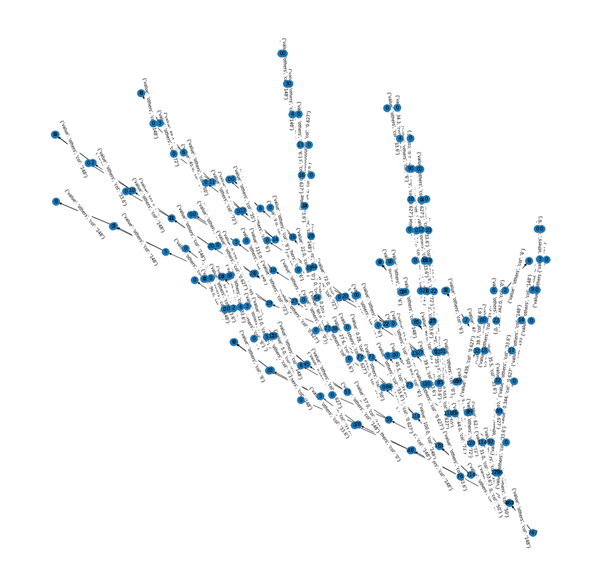

```python
filename2 = 'indians_diabetes.csv'
d_tree3 = grow_and_show_tree(filename2, pruning=True,threshold=0.9)
```

Jak możemy zauważyć poniżej, nasz model zaklasyfikował takie parametry jako osobę zdrową (klasa 0). Dokładność 0.98 świadczy o tym, że dla danego liścia stosunek miedzy klasą o największej liczności a pozostałymi wynosi 0.98 : 0.02 (jako że klasyfikujemy obserwację do bardziej licznej klasy, w tym przypadku była nią klasa 0).

```python
print(predict([6,84,66,15,0,23,0.304,21], d_tree3))
```

```
{'predykcja': 0.0, 'liczba': 149, 'dokladnosc': 0.9867549668874173}
```

Poniżej powtórzymy operację dla uproszczonej wersji bardzo dobrze znanego wszystkim datasetu iris. Zawiera on informację o parametrach kwiatu (dotyczące działki kielicha i płatków kwiatu) oraz przyporządkowane etykiety wskazujące na jego gatunek:

- Iris Setosa
- Iris Versicolour
- Iris Virginica

```
id=8736671337301 Column ps: x >= 3.0?
yes -> id=8736682233913 Column pw: x >= 1.8?
		yes -> id=8736671209609 Column ps: x >= 4.9?
				yes -> {' virginica': 43}
				no  -> id=8736701237893 Column sp: x >= 6.0?
						yes -> {' virginica': 2}
						no  -> {' versicolor': 1}
		no  -> id=8736682233321 Column ps: x >= 5.0?
				yes -> id=8736682233293 Column pw: x >= 1.6?
						yes -> id=8736682233325 Column sp: x >= 7.2?
								yes -> {' virginica': 1}
								no  -> {' versicolor': 2}
						no  -> {' virginica': 3}
				no  -> id=8736682233317 Column pw: x >= 1.7?
						yes -> {' virginica': 1}
						no  -> {' versicolor': 47}
no  -> {' setosa': 50}
Nastąpił pruning: zysk informacyjny = 0.146094
id=8736671337301 Column ps: x >= 3.0?
yes -> id=8736682233913 Column pw: x >= 1.8?
		yes -> id=8736671209609 Column ps: x >= 4.9?
				yes -> {' virginica': 43}
				no  -> id=8736701237893 Column sp: x >= 6.0?
						yes -> {' virginica': 2}
						no  -> {' versicolor': 1}
		no  -> id=8736682233321 Column ps: x >= 5.0?
				yes -> id=8736682233293 Column pw: x >= 1.6?
						yes -> id=8736682233325 Column sp: x >= 7.2?
								yes -> {' virginica': 1}
								no  -> {' versicolor': 2}
						no  -> {' virginica': 3}
				no  -> {'a': 1, 'r': 47}
no  -> {' setosa': 50}
```

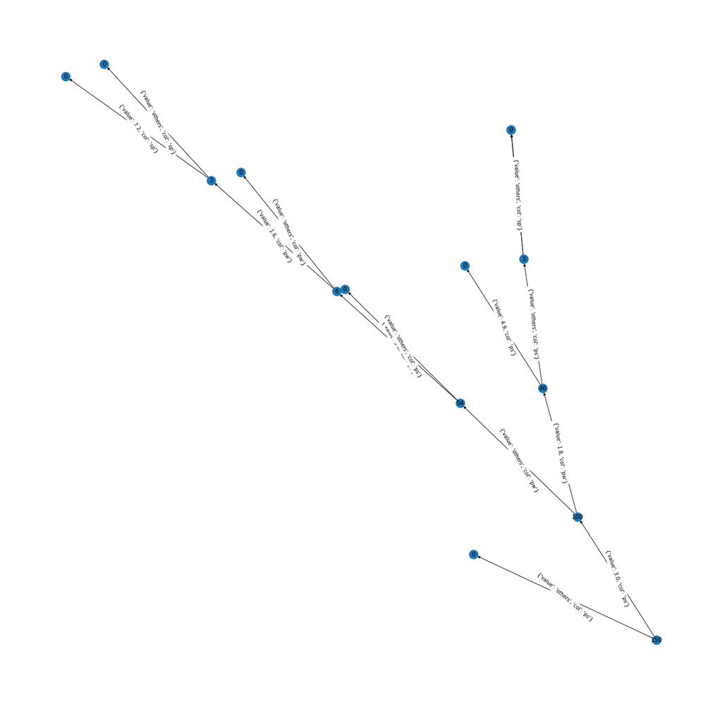

```python
filename3 = 'iris.csv'
d_tree4 = grow_and_show_tree(filename3, pruning=True,threshold=0.5)
```

W tym przypadku pruning nastąpił tylko raz, a drzewo jest znacznie mniej rozbudowane.

Ponownie poniżej przedstawimy predykcję danych do klasy.

```python
print(predict([6.1, 2.0, 5.0, 1.7], d_tree4))
```

```
{'predykcja': ' versicolor', 'liczba': 2, 'dokladnosc': 1.0}
```

Jak możemy zauważyć dla zadanych parametrów drzewo zostało zaklasyfikowane jako versicolor. Dokładność 1.0 oznacza, że w tym liściu wszystkie outputy miały właśnie taką etykietę.